# JAX for Beginners, Novices and Experts

# What's going on?

### -> The overhead of setting up vectorisation is greater than speed up of the vectorised operation over the loop (because of arrays are small)

## Now `vmap()` and time it (with larger arrays)

```python
x = jnp.ones(shape = (1000,3))
y = jnp.ones(shape = (1000,3))
# Make some large data arrays
```

```python
%timeit _ = naive_custom_dot(x,y)
# Quite slow
```

```
192 ms ± 10.3 ms per loop (mean ± std. dev. of 7 runs, 1 loop each)
```

```python
%timeit _ = batched_custom_dot(x,y)
# Faster than looping with large arrays
```

```
1.2 ms ± 98.4 µs per loop (mean ± std. dev. of 7 runs, 1,000 loops each)
```

## Bonus : Now `jit()` it *and* `vmap()` it

```python
jitted_batched_custom_dot = jax.jit(batched_custom_dot)
```

```python
%timeit _ = jitted_batched_custom_dot(x,y)
# Now even faster
```

```
12.3 µs ± 243 ns per loop (mean ± std. dev. of 7 runs, 100,000 loops each)
```

# `pmap()`

- `pmap()` has similar logic to `vmap()`
- Now a function is broadcast to several devices
- Also does compilation (same as applying `jit()`)

API is likely to change, possibly `pmap()` will be deprecated for `xmap()`

# `grad()`

- Returns a function that calculates the gradient of a function
- Consider $x^{2}$
- We know its derivative to be $2x$

```python
x = jnp.arange(0,10,0.500)
```

```python
def square_func(x):
    return x*x
```

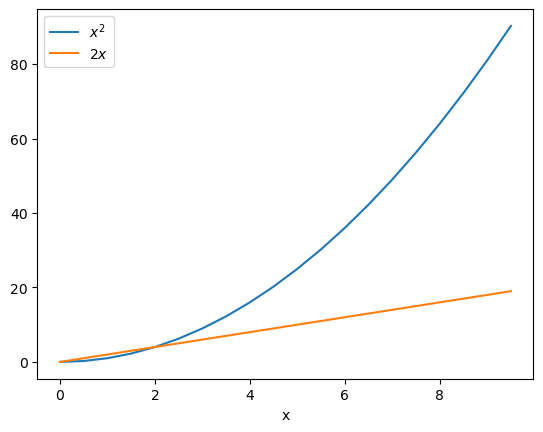

```python
_ = plt.plot(x,square_func(x),label = '$x^{2}$')
_ = plt.plot(x,2*x,label = '$2x$')
_ = plt.legend()
_ = plt.xlabel('x')
```

```python
square_grad = jax.grad(square_func)
```

```python
grad_vals = jax.vmap(square_grad)(x)
```

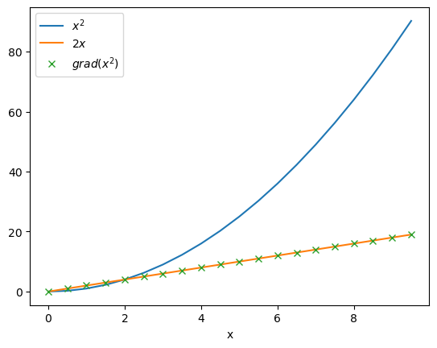

```python
_ = plt.plot(x,square_func(x),label = '$x^{2}$')
_ = plt.plot(x,2*x,label = '$2x$')
_ = plt.plot(x,grad_vals,'x',label = '$grad(x^{2})$')
_ = plt.legend()
_ = plt.xlabel('x')
```

## This is amazing

```python
%%html
<iframe src="https://giphy.com/embed/26ufdipQqU2lhNA4g" width="480" height="480" style="" frameBorder="0" class="giphy-embed" allowFullScreen></iframe><p><a href="https://giphy.com/gifs/producthunt-mind-blown-blow-your-26ufdipQqU2lhNA4g">via GIPHY</a></p>
```

[interactive chart not shown]

[via GIPHY](https://giphy.com/gifs/producthunt-mind-blown-blow-your-26ufdipQqU2lhNA4g)

- Instead of
  - Coding a function
  - Calculating the derivative by hand
  - Coding the derivative
- We can calculate the derivative directly as a new function

Consider $f(x) = tanh(sin(cos(e^{x})))$

```python
def crazy_func(x):
    return jnp.tanh(jnp.sin(jnp.cos(jnp.exp(x))))
```

```python
x = jnp.arange(0,5,0.100)
```

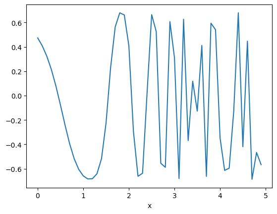

```python
_ = plt.plot(x,crazy_func(x))
_ = plt.xlabel('x')
```

```python
crazy_func_grad = jax.grad(crazy_func)
```

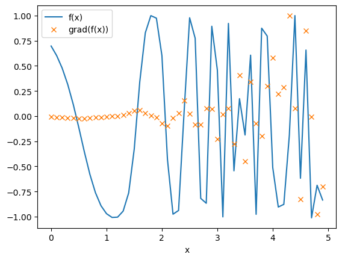

```python
_ = plt.plot(x,crazy_func(x)/jnp.max(crazy_func(x)),label = 'f(x)')
_ = plt.plot(x,jax.vmap(crazy_func_grad)(x)/jnp.max(jax.vmap(crazy_func_grad)(x)),'x',label = 'grad(f(x))')
_ = plt.xlabel('x')
_ = plt.legend()
```

# Jax: Experts

## JAX as a gradient centric accelerated functional programming language

## Main concepts

1. Automatic Differentiation
2. Functional Programming

# 1. Auto Diff

## (Algorithmic differentiation, AutoGrad)

## There are three methods to calculate a gradient

- Symbolic differentation
- Numerical differentiation
- Algorithmic differentiation
- Algorithmic differentiation underlies back-propagation
- Allows for weights in complex neural networks to be updated
- Represents a whole branch of optimisation (gradient-based optimisation)

[figure not shown]

[Read more: alexey.radul.name/ideas/2013/introduction-to-automatic-differentiation/]

# 2. Functional Programming

- This a distinct style of programming
- Lisp, Perl, Spark are all primarily functional programming languages
- Python, C primarily imperative programming languages

## How do I know if I am doing functional programming?

- Lots of functions!
- No 'side-effects' or 'state'
- Data structures are immutable
- Maps instead of loops

## Comparison to Imperative Programming [[source]](https://en.wikipedia.org/wiki/Functional_programming#Imperative_vs._functional_programming)

```python
const numList = [1, 2, 3, 4, 5, 6, 7, 8, 9, 10];
let result = 0;
for (let i = 0; i < numList.length; i++) {
  if (numList[i] % 2 === 0) {
    result += numList[i] * 10;
  }
}
# Imperative
```

```
  Cell In[45], line 1
    const numList = [1, 2, 3, 4, 5, 6, 7, 8, 9, 10];
          ^
SyntaxError: invalid syntax
```

```python
const result = [1, 2, 3, 4, 5, 6, 7, 8, 9, 10]
               .filter(n => n % 2 === 0)
               .map(a => a * 10)
               .reduce((a, b) => a + b, 0);
# Functional
```

## These concepts underly JAX

- If functions are 'pure', they can be 'traced'
- Tracing allows JAX to differentiate nested functions of arbitrary complexity
- Including loops, random numbers, control structures (!)

## To be aware of

- These capabilities come with some caveats
- Must be aware of JAX constraints
- Particularly random numbers, JAX friendly versions of functions etc

[[JAX - The sharp bits](https://jax.readthedocs.io/en/latest/notebooks/Common_Gotchas_in_JAX.html)]

# Functions with control structures

```python
def naive_cond_func(x):

    if x > 1.0:
        return 1.0
    else:
        return 0.0
    # Use standard if/else
```

```python
naive_cond_func(0.9),naive_cond_func(1.1)
# Fine
```

```
(0.0, 1.0)
```

```python
grad_naive_cond_func = jax.grad(naive_cond_func)
grad_naive_cond_func(1.1)
# Also fine
```

```
Array(0., dtype=float32, weak_type=True)
```

```python
jax.jit(naive_cond_func)(3.)
# Not fine
```

```
---------------------------------------------------------------------------
TracerBoolConversionError                 Traceback (most recent call last)
Cell In[49], line 1
----> 1 jax.jit(naive_cond_func)(3.)
      2 # Not fine

    [... skipping hidden 12 frame]

Cell In[46], line 3, in naive_cond_func(x)
      1 def naive_cond_func(x):
----> 3     if x > 1.0:
      4         return 1.0
      5     else:

    [... skipping hidden 1 frame]

File ~/anaconda3/lib/python3.10/site-packages/jax/_src/core.py:1510, in concretization_function_error.<locals>.error(self, arg)
   1509 def error(self, arg):
-> 1510   raise TracerBoolConversionError(arg)

TracerBoolConversionError: Attempted boolean conversion of traced array with shape bool[]..
The error occurred while tracing the function naive_cond_func at /var/folders/k1/53y5f3kj0ds7q7r6fdjsn2kc0000gn/T/ipykernel_76342/917762618.py:1 for jit. This concrete value was not available in Python because it depends on the value of the argument x.
See https://jax.readthedocs.io/en/latest/errors.html#jax.errors.TracerBoolConversionError
```

## Use JAX friendly operators (`jnp.where()`)

```python
def jax_cond_func(x):
    return jnp.where(x > 1, 1.0, 0.0)
    # Important to use JAX friendly operators like jnp.where
    # Simple if/else will throw an error
```

```python
jax_cond_func(1.1),jax_cond_func(0.1)
```

```
(Array(1., dtype=float32, weak_type=True),
 Array(0., dtype=float32, weak_type=True))
```

```python
grad_jax_cond_func = jax.grad(jax_cond_func)
grad_jax_cond_func(1.0)
```

```
Array(0., dtype=float32, weak_type=True)
```

```python
jax.jit(jax_cond_func)(0.5)
# Now this is fine
```

```
Array(0., dtype=float32, weak_type=True)
```

# Functions with random numbers

### *In order to be reproducible and vectorisable, random numbers in JAX work differently*

- Necessary to keep track of state of random number generator
- Pass a key to each random number call
- Use each key only once!
- The key can be split to make new keys

```python
from jax import random

key = random.key(42)
print(key)
```

```
Array((), dtype=key<fry>) overlaying:
[ 0 42]
```

```python
print(random.normal(key))
print(random.normal(key))
# Using the same key twice gives the same result
```

```
-0.18471177
-0.18471177
```

```python
random.normal(key,[10])
# You can use a key to make more than one sample
```

```
Array([ 0.36900434, -0.46067542, -0.8650934 ,  1.2080883 ,  1.003065  ,
       -0.8708058 , -0.3984997 , -0.6670092 ,  0.33689356,  0.39822492],      dtype=float32)
```

```python
key, subkey = random.split(key)
```

```python
random.normal(subkey,[10])
```

```
Array([-1.6652092 ,  0.23443979, -0.24498989,  0.44707215,  0.2563031 ,
        0.28259823, -0.11017016,  0.5699527 ,  0.33960482, -1.7104207 ],      dtype=float32)
```

```python
key, subkey = random.split(key)
# Get another subkey
```

```python
random.normal(subkey,[10])
```

```
Array([ 0.3775522 ,  0.86482465,  0.35859048, -1.3558996 , -1.3783264 ,
       -1.6572771 , -0.9572237 , -0.6402885 ,  1.7951181 ,  2.5553172 ],      dtype=float32)
```

# Random Number Generation: Example

```python
global global_key
# Define key as a global variable
```

```python
global_key = random.key(42)
```

```python
global_key
```

```
Array((), dtype=key<fry>) overlaying:
[ 0 42]
```

```python
def rand_func(x):

    global global_key

    print('\tBefore:',global_key)

    global_key, subkey = random.split(global_key)
    # Split global_key, keep one of the new keys

    r = jax.random.uniform(shape = [1],key = subkey,minval = 0.0, maxval = 1.0)
    # Use the subkey

    print('\tAfter:',global_key)

    return jnp.where(r > 0.5, x, 0.0)[0]
```

```python
for i in range(5):
    print('-> ',rand_func(i))
```

```
	Before: Array((), dtype=key<fry>) overlaying:
[3293111712  223174505]
	After: Array((), dtype=key<fry>) overlaying:
[2450444690 3385185863]
->  0.0
	Before: Array((), dtype=key<fry>) overlaying:
[2450444690 3385185863]
	After: Array((), dtype=key<fry>) overlaying:
[4154672267 4261516360]
->  1.0
	Before: Array((), dtype=key<fry>) overlaying:
[4154672267 4261516360]
	After: Array((), dtype=key<fry>) overlaying:
[281466122 635023318]
->  0.0
	Before: Array((), dtype=key<fry>) overlaying:
[281466122 635023318]
	After: Array((), dtype=key<fry>) overlaying:
[1720602109 2734323023]
->  0.0
	Before: Array((), dtype=key<fry>) overlaying:
[1720602109 2734323023]
	After: Array((), dtype=key<fry>) overlaying:
[2227035060 2872287042]
->  4.0
```

```python
jax.grad(rand_func)(1.0)
# Now we can take the grad of this random function
```

```
	Before: Array((), dtype=key<fry>) overlaying:
[4046737378 1557832356]
	After: Array((), dtype=key<fry>) overlaying:
[590074140 438467548]
```

```
Array(0., dtype=float32)
```

# What can I use JAX for?

- Quick optimisation of existing Python code using `jit()`
- Quickly scaling up ML prototypes
- Directly accessing gradients in complex ML/RL simulations
- Refactoring optimisation problems into gradient-based optimisation

# Learn More

## Beginner

- [Video] [Intro to Jax](https://www.youtube.com/watch?v=WdTeDXsOSj4)

## Novice

- [Notebooks] [Jax cookbook](https://www.kaggle.com/code/truthr/learn-jax-from-linear-regression-to-neural-networ?scriptVersionId=91121887)

## Expert

- [Blog] [Intro to Auto Diff](https://alexey.radul.name/ideas/2013/introduction-to-automatic-differentiation/)
- [Video] [DeepMind Session on Jax Ecosystem](https://www.youtube.com/watch?v=iDxJxIyzSiM)
- [Video] [Intro to JaxMD](https://www.youtube.com/watch?v=Bkm8tGET7-w&t=2486s)

# In Summary

[figure not shown]

```python
%watermark -iv
```

```
jax       : 0.4.23
numpy     : 1.26.4
keras     : 3.4.1
matplotlib: 3.8.4
```

```python
jax.make_jaxpr(my_func_jitted)(x)
```

```
{ lambda ; a:f32[50]. let
    b:f32[50] = pjit[
      name=my_func
      jaxpr={ lambda ; c:f32[50]. let
          d:f32[50] = integer_pow[y=2] c
          e:f32[50] = add d 1.0
        in (e,) }
    ] a
  in (b,) }
```

```python
??my_func
```